# Cargando Biblioteca

```r
library(ggplot2)
```

# Cargar y preprocesar los datos

## Cargar los datos

```r
fullData <- read.csv("activity.csv")
```

# Procesar/transformar los datos

```r
fullData$date <- as.Date(fullData$date, "%Y-%m-%d")
```

# A. ¿Cuál es el número total medio de pasos dados por día?

## Calcular el total de pasos por día

```r
stepsPerDay <- aggregate(steps ~ date, fullData, FUN = sum)
```

## Haz un histograma del número total de pasos dados cada día.

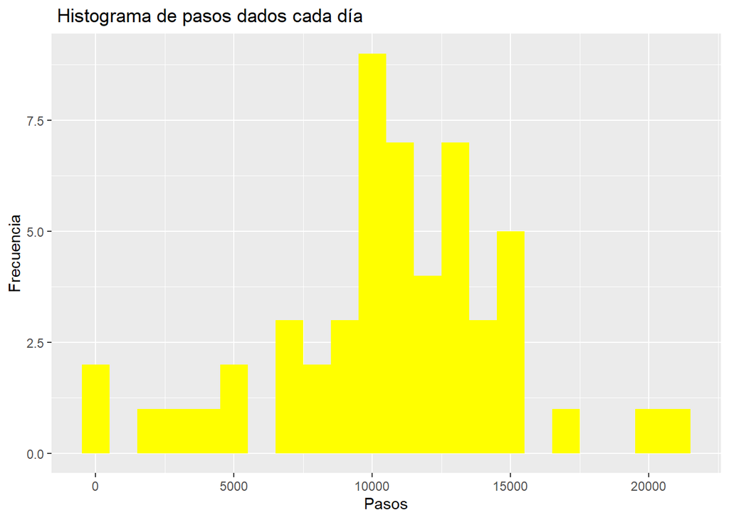

```r
library(ggplot2)

g <- ggplot (stepsPerDay, aes (x = steps))

g + geom_histogram(fill = "yellow", binwidth = 1000) +
    labs(title = " Histograma de pasos dados cada día ", x = "Pasos", y = "Frecuencia")
```

## Calcule e informe la media y la mediana del número total de pasos dados por día

```r
stepsMean <- mean(stepsPerDay$steps, na.rm=TRUE)
stepsMean
```

```
## [1] 10766.19
```

```r
stepsMedian <- median(stepsPerDay$steps, na.rm=TRUE)
stepsMedian
```

```
## [1] 10765
```

## La media y la mediana del número total de pasos dados por día son 10766.19 y 10765 respectivamente

# B. ¿Cuál es el patrón de actividad diario promedio?

## Haga un gráfico de serie de tiempo (es decir, tipo = “l”) del intervalo de 5 minutos (eje x) y el número promedio de pasos dados, promediado en todos los días (eje y)

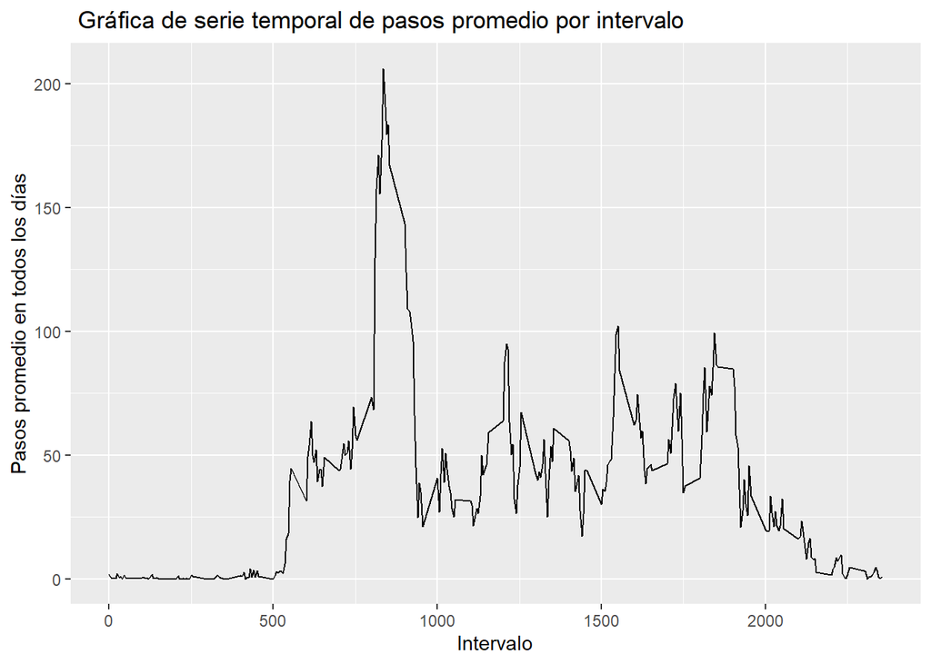

```r
stepsPerInterval <- aggregate(steps ~ interval, fullData, mean)

# Cree una gráfica de serie temporal del número promedio de pasos por intervalo, anote la gráfica
h <- ggplot (stepsPerInterval, aes(x=interval, y=steps))
h + geom_line()+ labs(title = " Gráfica de serie temporal de pasos promedio por intervalo", x = "Intervalo", y = "Pasos promedio en todos los días")
```

## ¿Qué intervalo de 5 minutos, en promedio de todos los días del conjunto de datos, contiene la cantidad máxima de pasos?

```r
maxInterval <- stepsPerInterval[which.max(stepsPerInterval$steps), ]
maxInterval
```

```
##     interval    steps
## 104      835 206.1698
```

# C. Imputación del valor faltante

## Calcule e informe el número total de valores faltantes en el conjunto de datos (es decir, el número total de filas con NA)

```r
noMissingValue <- nrow(fullData[is.na(fullData$steps),])
noMissingValue
```

```
## [1] 2304
```

## Diseñe una estrategia para completar todos los valores que faltan en el conjunto de datos. La estrategia no necesita ser sofisticada. Por ejemplo, podría usar la media/mediana de ese día, o la media de ese intervalo de 5 minutos, etc.

## Mi estrategia para completar los valores faltantes (NA) es sustituir los valores faltantes (pasos) con el número promedio de pasos según el intervalo de 5 minutos y el día de la semana.

```r
fullData1 <- read.csv("activity.csv", header=TRUE,sep=",")

# Cree una variable/columna con el nombre de los días de la semana
fullData1$day <- weekdays(as.Date(fullData1$date))

# crear un número promedio de pasos por intervalo de 5 minutos y día
stepsAvg1 <- aggregate(steps ~ interval + day, fullData1, mean)

# Cree un conjunto de datos con todas las NA para la sustitución
nadata <- fullData1 [is.na(fullData1$steps),]

# Combine el conjunto de datos NA con los pasos promedio basados en intervalos de 5 minutos + días de la semana, para sustituciones
newdata1 <- merge(nadata, stepsAvg1, by=c("interval", "day"))
```

## Cree un nuevo conjunto de datos que sea igual al conjunto de datos original pero con los datos faltantes completados.

```r
cleanData <- fullData1 [!is.na(fullData1$steps),]

#Vuelva a ordenar los nuevos datos sustituidos en el mismo formato que el conjunto de datos limpio (omita la columna NA que se sustituirá por los pasos promedio en función del intervalo de 5 minutos + día)
newdata2 <- newdata1[,c(5,4,1,2)]
colnames(newdata2) <- c("steps", "date", "interval", "day")

# Combinar los nuevos datos promedio (NA) con el conjunto de datos sin NA
mergeData <- rbind (cleanData, newdata2)
```

## Haga un histograma del número total de pasos dados cada día y Calcule e informe la media y la mediana del número total de pasos dados por día. ¿Estos valores difieren de las estimaciones de la primera parte de la tarea? ¿Cuál es el impacto de imputar los datos que faltan en las estimaciones del número total diario de pasos?

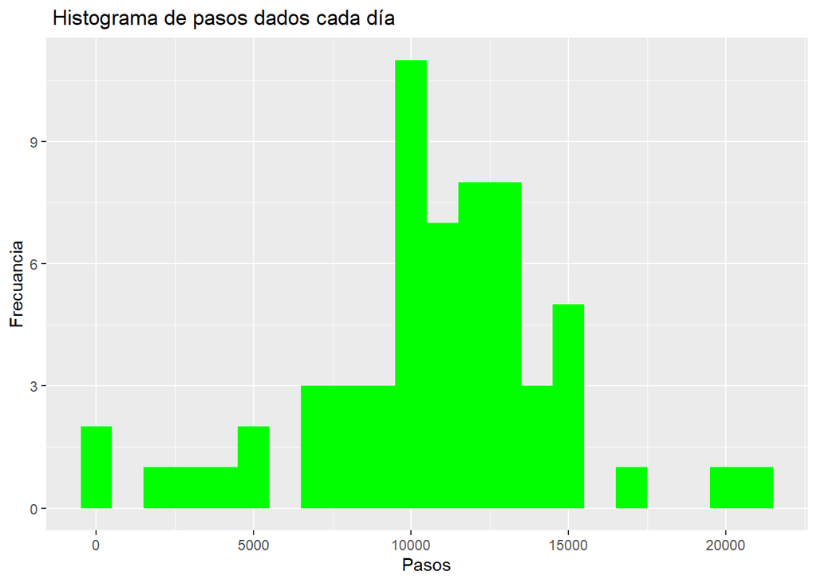

```r
# Calcule el total de pasos por día en los datos combinados
stepsPerDayFill <- aggregate(steps ~ date, mergeData, FUN = sum)

# Crear el histograma
g1 <- ggplot (stepsPerDayFill, aes (x = steps))
g1 + geom_histogram(fill = "green", binwidth = 1000) +
    labs(title = " Histograma de pasos dados cada día ", x = "Pasos", y = "Frecuancia")
```

```r
stepsMeanFill <- mean(stepsPerDayFill$steps, na.rm=TRUE)
stepsMeanFill
```

```
## [1] 10821.21
```

```r
# Mediana del total de pasos con datos imputados
stepsMedianFill <- median(stepsPerDayFill$steps, na.rm=TRUE)
stepsMedianFill
```

```
## [1] 11015
```

## Sin embargo, la forma general de la distribución no ha cambiado.

# D. ¿Existen diferencias en los patrones de actividad entre los días de semana y los fines de semana?

```r
#cree una nueva variable/columna que indique el día de la semana o el fin de semana
mergeData$DayType <- ifelse(mergeData$day %in% c("Saturday", "Sunday"), "Weekend", "Weekday")
```

[figure not shown]

```r
# crear una tabla con pasos promedio por intervalo de tiempo entre los días de semana o los días de fin de semana
stepsPerIntervalDT <- aggregate(steps ~ interval+DayType, mergeData, FUN = mean)
# Haz el diagrama de panel
j <- ggplot (stepsPerIntervalDT, aes(x=interval, y=steps))
j + geom_line()+ labs(title = " Gráfica de serie temporal de pasos promedio por intervalo: días de semana frente a fines de semana", x = "Intervalo", y = "Número promedio de pasos") + facet_grid(DayType ~ .)
```